# User Data

### Get Data

```r
if(!require(easypackages)){install.packages("easypackages")}
library(easypackages)
packages("plyr", "dplyr", "data.table", "xda","ggplot2", "forcats", "readr", "gridExtra",  prompt = FALSE)
#data.table used only for fread
```

```r
Users <- read_csv("C:/Users/cweaver/Downloads/Users/Users.csv", col_types = cols(StoreId = col_integer()), progress = FALSE)
myData <- Users
rm(Users)
```

```r
glimpse(myData)
```

```
## Observations: 17,516,305
## Variables: 48
## $ UserId                     <int> 1, 2, 3, 7, 8, 1059, 1169, 1172, 11...
## $ StoreId                    <int> NA, NA, 0, 0, NA, 1, 1, 1, 1, 1, 1,...
## $ CheckInCredentialsModified <int> 0, 1, 1, 1, 1, 0, 0, 0, 0, 0, 0, 0,...
## $ Gender                     <chr> "NULL", "NULL", "M", "M", "NULL", "...
## $ UserType                   <chr> "CrStaff", "CrStaff", "CrStaff", "D...
## $ Amenities                  <int> 0, 0, 0, 0, 0, 0, 0, 0, 0, 0, 0, 0,...
## $ Tags                       <int> 0, 0, 0, 0, 0, 0, 0, 0, 0, 0, 0, 0,...
## $ Checkins                   <int> 0, 0, 0, 0, 0, 0, 1, 0, 0, 9, 3, 1,...
## $ Checkins_Sunday            <int> 0, 0, 0, 0, 0, 0, 0, 0, 0, 1, 1, 0,...
## $ Checkins_Monday            <int> 0, 0, 0, 0, 0, 0, 0, 0, 0, 2, 0, 1,...
## $ Checkins_Tuesday           <int> 0, 0, 0, 0, 0, 0, 0, 0, 0, 0, 1, 0,...
## $ Checkins_Wednesday         <int> 0, 0, 0, 0, 0, 0, 0, 0, 0, 0, 1, 0,...
## $ Checkins_Thursday          <int> 0, 0, 0, 0, 0, 0, 1, 0, 0, 5, 0, 0,...
```

[output cut: 35 more lines]

### Remove NA

There do not appear to be as many `NAs` as we have seen before. This time they appear prevalent in the `StoreId` varaible. Also note `NULL` in the `Gender` field.

```r
myData <- myData %>%  mutate_if(is.integer, funs(replace(., is.na(.), 0)))#changes int to dbl
myData[,-41] <- myData %>%  mutate_if(is.double, as.integer)#return to int
glimpse(myData$StoreId)
```

```
##  int [1:17516305] 0 0 0 0 0 1 1 1 1 1 ...
```

`StoreId` looks better now.

### Character to Factors

`Gender` and `UserType` are charcater variables. Change them to factors.

```r
myData <- myData %>% mutate_if(is.character, as.factor)
charSummary(myData)
```

```
##                 n miss        miss% unique
## Gender   17516304    1 5.708967e-06     20
## UserType 17516305    0 0.000000e+00     13
##                                                                                                            top5levels:count
## Gender                                                     F:6181600, M:5638707, NULL:2834500, Female:1527379, Male:1321975
## UserType ClubClient:15676776, DeletedClubClient:1645260, ClubClientTemporary:63819, DeletedClubAdmin:62840, ClubAdmin:55389
```

```r
myData_factor <- myData %>% select_if(is.factor)
```

Note `Gender` appears to have many missing values. These will be managed a bit later

### Tables for the Factors

Examine the factors in the working dataset.

```r
for(i in 1:length(myData_factor)){
  print(names(myData_factor[i]))
  print(table(myData_factor[i]))
}
```

```
## [1] "Gender"
##
##         "         1     Erkek         f         F    female    Female
##         1         6         2      2326   6181600      3700   1527379
##         g     Kadin         m         M      male      Male Masculino
##         1         1      2349   5638707      2734   1321975         1
##         n      NULL         p         u         U
##       133   2834500         1        39       849
## [1] "UserType"
##
##                 CAS           ClubAdmin          ClubClient
##                   5               55389            15676776
## ClubClientTemporary         ClubTrainer           CorpAdmin
##               63819                 823                3256
##             CrStaff    DeletedClubAdmin   DeletedClubClient
##                 165               62840             1645260
##  DeletedClubTrainer    DeletedCorpAdmin      DeletedCrStaff
##                2776                2263                 164
##      Duplicate User
##                2769
```

```r
rm(myData_factor)
```

There is much work to do on the `Gender` variable. Will also choose the appropriate `UserType` values for modeling.

#### User Factor - Gender

The values in `Gender` are varied. These will need to be collaspers into a couple of factor levels.

```r
#Factor - Gender
myData %>% group_by(Gender) %>% summarize(Unique_Values = n()) %>% arrange(desc(Unique_Values))
```

```
## # A tibble: 20 x 2
##       Gender Unique_Values
##       <fctr>         <int>
##  1         F       6181600
##  2         M       5638707
##  3      NULL       2834500
##  4    Female       1527379
##  5      Male       1321975
##  6    female          3700
##  7      male          2734
##  8         m          2349
##  9         f          2326
## 10         U           849
## 11         n           133
## 12         u            39
## 13         1             6
## 14     Erkek             2
## 15      "\""             1
## 16         g             1
## 17     Kadin             1
## 18 Masculino             1
## 19         p             1
## 20      <NA>             1
```

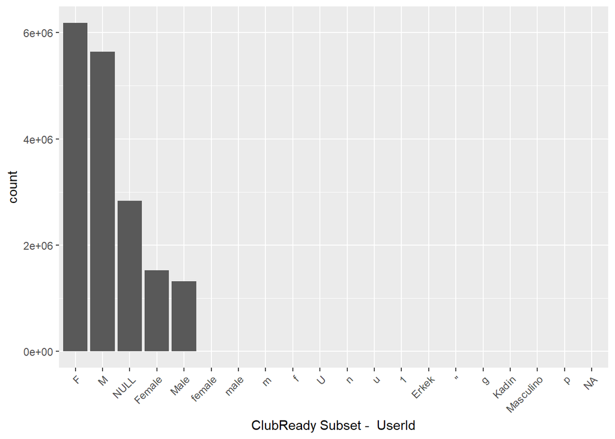

```r
ggplot(myData, aes(fct_infreq(Gender))) + geom_bar() + xlab(paste("ClubReady Subset - ", names(myData)[1])) +
  theme(axis.text.x = element_text(angle = 45, hjust = 1))
```

```r
levels(myData$Gender)[levels(myData$Gender) == "F"] <- "Female"
levels(myData$Gender)[levels(myData$Gender) == "female"] <- "Female"
levels(myData$Gender)[levels(myData$Gender) == "f"] <- "Female"

levels(myData$Gender)[levels(myData$Gender) == "M"] <- "Male"
levels(myData$Gender)[levels(myData$Gender) == "male"] <- "Male"
levels(myData$Gender)[levels(myData$Gender) == "m"] <- "Male"

myData %>% group_by(Gender) %>% summarize(Unique_Values = n()) %>% arrange(desc(Unique_Values))
```

```
## # A tibble: 14 x 2
##       Gender Unique_Values
##       <fctr>         <int>
##  1    Female       7715005
##  2      Male       6965765
##  3      NULL       2834500
##  4         U           849
##  5         n           133
##  6         u            39
##  7         1             6
##  8     Erkek             2
##  9      "\""             1
## 10         g             1
## 11     Kadin             1
## 12 Masculino             1
## 13         p             1
## 14      <NA>             1
```

This looks better but there are still suspect values. We will remove:

- All the `Gender` value counts that are small will be removed. This affects everything from `U` and below in the table above.
- It is reasonable to assume `Gender` is an informative variable in churn modeling. Valorem will initally remove the `NULL` values from `Gender`. **Note to Brad**

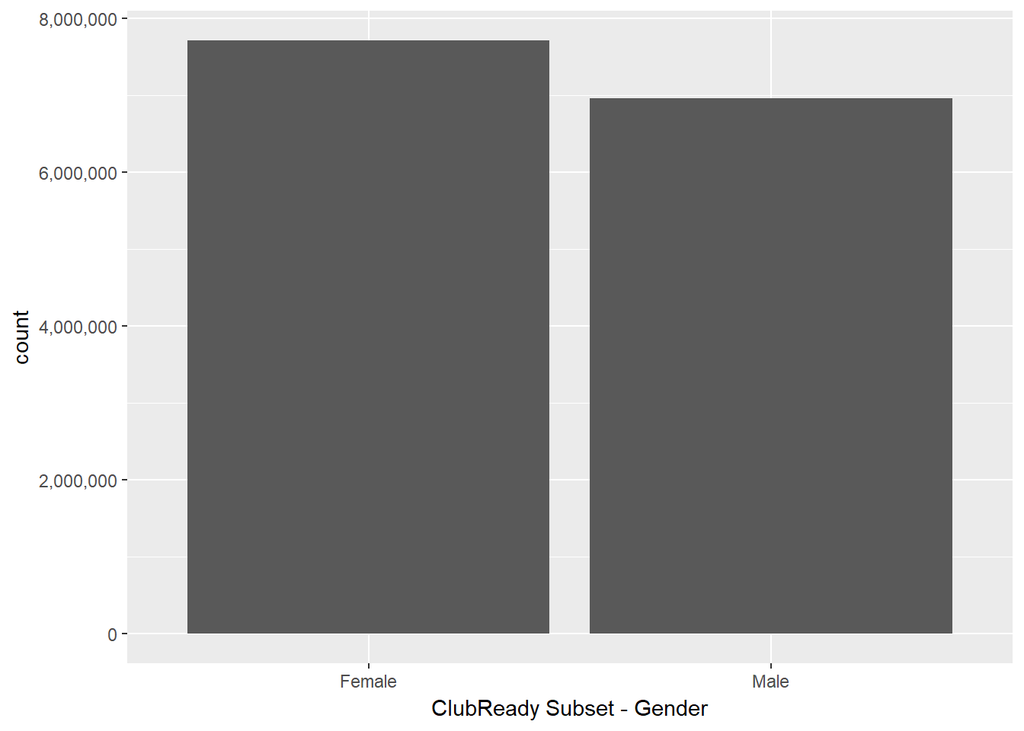

```r
myData <- filter(myData, Gender == "Female" | Gender == "Male")
myData$Gender <- factor(myData$Gender)

ggplot(myData, aes(fct_infreq(Gender))) + geom_bar() + xlab("ClubReady Subset - Gender") +
  scale_y_continuous(labels = scales::comma)
```

#### User Factor - UserType

```r
myData %>% group_by(UserType) %>% summarize(Unique_Values = n()) %>% arrange(desc(Unique_Values))
```

```
## # A tibble: 13 x 2
##               UserType Unique_Values
##                 <fctr>         <int>
##  1          ClubClient      13111028
##  2   DeletedClubClient       1425029
##  3    DeletedClubAdmin         56073
##  4           ClubAdmin         44420
##  5 ClubClientTemporary         32757
##  6           CorpAdmin          3221
##  7  DeletedClubTrainer          2773
##  8    DeletedCorpAdmin          2250
##  9      Duplicate User          2210
## 10         ClubTrainer           819
## 11             CrStaff           106
## 12      DeletedCrStaff            79
## 13                 CAS             5
```

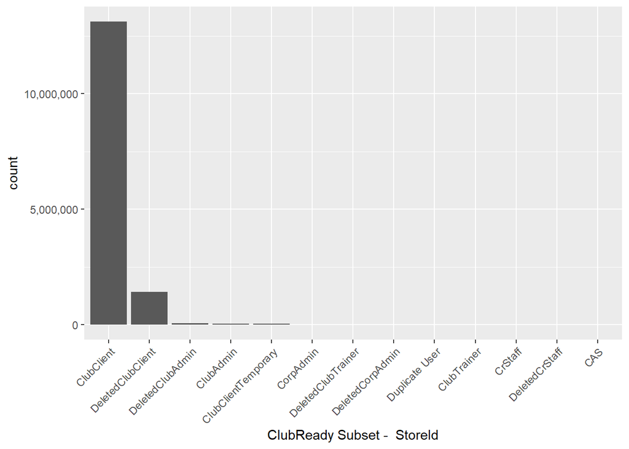

```r
ggplot(myData, aes(fct_infreq(UserType))) + geom_bar() + xlab(paste("ClubReady Subset - ", names(myData)[2])) +
  theme(axis.text.x = element_text(angle = 45, hjust = 1)) + scale_y_continuous(labels = scales::comma)
```

ClubReady confirmed Valorem to use:

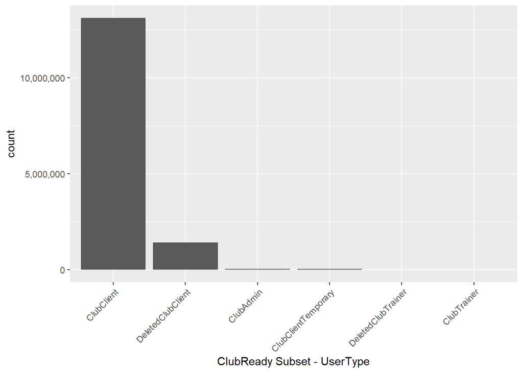

```r
myData <- filter(myData, UserType == 'ClubClient' | UserType == 'DeletedClubClient' | UserType == 'ClubAdmin' | UserType == 'ClubTrainer' | UserType == 'DeletedClubTrainer' | UserType == 'ClubClientTemporary')
myData$UserType <- factor(myData$UserType)

ggplot(myData, aes(fct_infreq(UserType))) + geom_bar() + xlab("ClubReady Subset - UserType") +
  theme(axis.text.x = element_text(angle = 45, hjust = 1)) + scale_y_continuous(labels = scales::comma)
```

Given the distribution above, Valorem may remove the infrequesntly used `UserType` values. **Note to Brad**

### Evaluate Numerical Data - had to take random sample b/c csv too large

> Because of the large number of `User` records, a random sample is selected in the code below.

```r
myNumSum <- numSummary(sample_frac(myData, .3))[, c(1,7,8,16,17)]
myNumSum <- tibble::rownames_to_column(myNumSum)
names(myNumSum)[5] <- "missPCT"
names(myNumSum)[1] <- "Variable_Name"
myNumSum <- arrange(myNumSum, desc(missPCT))
head(myNumSum, 20)
```

```
##                 Variable_Name       n nunique  nzeros missPCT miss%
## 1                      UserId 4385048 4385048       0       0     0
## 2                     StoreId 4385048    3852    2595       0     0
## 3  CheckInCredentialsModified 4385048       2  483189       0     0
## 4                   Amenities 4385048      39 4236323       0     0
## 5                        Tags 4385048       6 4363755       0     0
## 6                    Checkins 4385048    1968 3232150       0     0
## 7             Checkins_Sunday 4385048     383 3935867       0     0
## 8             Checkins_Monday 4385048     499 3510228       0     0
## 9            Checkins_Tuesday 4385048     500 3512575       0     0
## 10         Checkins_Wednesday 4385048     497 3514664       0     0
## 11          Checkins_Thursday 4385048     472 3545600       0     0
## 12            Checkins_Friday 4385048     463 3627158       0     0
## 13          Checkins_Saturday 4385048     408 3770039       0     0
## 14          Checkins_Hour0to1 4385048     495 4350101       0     0
## 15          Checkins_Hour1to2 4385048     134 4372707       0     0
## 16          Checkins_Hour2to3 4385048     136 4376296       0     0
## 17          Checkins_Hour3to4 4385048     224 4375209       0     0
## 18          Checkins_Hour4to5 4385048     507 4349167       0     0
## 19          Checkins_Hour5to6 4385048     769 4250389       0     0
## 20          Checkins_Hour6to7 4385048     659 4200143       0     0
```

No missing data is in the working dataset.

### Variance

```r
#Do not include UserId, StoreId, Gender, UserType, TotalSpent
myVariance <- as.data.frame(apply(myData[,-c(1,2,4,5,41)], 2, var))
myVariance <- tibble::rownames_to_column(myVariance)
names(myVariance)[2] <- "Variance"
myVariance <-  myVariance %>% mutate(Variance2 = ifelse(Variance == 0, "No", "Yes"))
table(myVariance$Variance2)
```

```
##
##  No Yes
##   1  42
```

Because 1 variables have no variance - all the values are the same, they can be removed from the working dataset. If there are no differences in a column, it is of no use in the development of an algorithm. The variables to be removed because there is no variance are:

```r
if(table(myVariance$Variance2)[1] > 0){
  VarNames <- myVariance %>% filter(Variance > 0) %>% select(rowname)
  zeroVarNames <- myVariance %>% filter(Variance == 0) %>% select(rowname)
  myData <- myData %>% select(UserId, StoreId, Gender, TotalSpent,  unlist(VarNames))
  zeroVarNames
}
```

```
##          rowname
## 1 RequiredWaiver
```

#### Outlier Detection

In the working dataset, there is one variable, `TotalSpent` that should be evaluated to identify any potential outlier. There are many way to visualize outliers. Boxplots are the most commonly used visualization.

```r
out3 <- ggplot(myData, aes(x = "", y = TotalSpent)) + geom_boxplot(outlier.color="red", outlier.shape=8, outlier.size=4) +
  scale_y_continuous(labels = scales::dollar)
```

```r
tmpRevDesc <- arrange(myData, desc(TotalSpent)) %>% select(TotalSpent)
tmpRevDesc <- tmpRevDesc[1:25,]
tmpRevDesc <- as.data.frame(scales::dollar(tmpRevDesc$TotalSpent))
names(tmpRevDesc) <- "Total_Spent"
```

```r
tmpRevAsc <- arrange(myData, TotalSpent) %>% select(TotalSpent)
tmpRevAsc <- tmpRevAsc[1:25,]
tmpRevAsc <- as.data.frame(scales::dollar(tmpRevAsc$TotalSpent))
names(tmpRevAsc) <- "Total_Spent"
```

```r
knitr::kable(list(tmpRevDesc, tmpRevAsc))
```

| Total_Spent |
| --- |
| $10,004,136 |
| $3,204,780 |
| $2,759,211 |
| $2,680,537 |
| $2,640,971 |
| $2,401,029 |
| $2,382,642 |
| $2,375,716 |
| $2,358,190 |
| $2,260,660 |
| $2,164,586 |
| $2,128,461 |
| $2,092,029 |
| $2,073,144 |
| $2,041,499 |
| $2,019,114 |
| $2,004,718 |
| $1,996,531 |
| $1,991,202 |
| $1,981,019 |
| $1,953,575 |
| $1,929,700 |
| $1,891,658 |
| $1,799,289 |
| $1,787,595 |

| Total_Spent |
| --- |
| $-638,972 |
| $-293,628 |
| $-42,475 |
| $-27,678 |
| $-18,986 |
| $-16,860 |
| $-16,254 |
| $-15,842 |
| $-14,992 |
| $-14,991 |
| $-14,542 |
| $-12,195 |
| $-10,793 |
| $-8,495 |
| $-7,579 |
| $-7,496 |
| $-6,207 |
| $-5,797 |
| $-4,245 |
| $-4,098 |
| $-4,098 |
| $-4,098 |
| $-3,995 |
| $-3,798 |
| $-3,398 |

### Duplication

```r
cat("The number of duplicated rows is", nrow(myData) - nrow(unique(myData)))
```

```
## The number of duplicated rows is 0
```

```r
if((nrow(myData) - nrow(unique(myData)))>0) myData[duplicated(myData),]
```

```r
if(nrow(myData) - nrow(unique(myData)) > 0){
  head(myData[duplicated(myData),])
  myData <- myData[!duplicated(myData),]
}
```

glimpse(myData)